[Voltar](http://victorpasson.github.io/)

# Prevendo Demanda de Estoque Baseado em Vendas - Grupo Bimbo

João Victor Vieira Passon - @victorpasson

27 de Dezembro de 2020

### **Visão Geral**

O objetivo principal desse projeto é solucionar um problema de negócio real, um desafio que quase todas as empresas enfrentam: prever a expectativa de Demanda para determinado produto. Com essa informação em mãos a empresa poderá atender seus clientes de maneira adequada, garantindo o fornecimento e reduzindo custos.

O Grupo Bimbo é uma empresa mexicana de fabricação de produtos de panificação que se encontra entre as mais importantes empresas do setor no mundo. O Grupo possui uma das maiores redes de distribuição, ultrapassando 52.000 rotas. Tudo isso graças ao posicionamento da marca, grande volume de produção e gigantesco número de vendas.

Os cálculos diário de estoque eram realizados por funcionários de vendas de entregas diretas, que deviam, sozinhos, prever a necessidade de estoque dos produtos e a demanda com base em suas experiências pessoais em cada loja.

Buscanco automatizar isso, ao final desse projeto, o algoritmo de Machine Learning deverá prever com precisão a demanda de estoque com base nos dados históricos de vendas. Isso fará com que os consumidores de suas lojas parceiras não fiquem olhando para prateleiras vazias, além de reduzir o valor gasto com retorno de produtos que não foram vendidos ou expiraram.

Para a construção desse projeto utilizaremos a Linguagem R.

Link para mais informações: https://www.kaggle.com/c/grupo-bimbo-inventory-demand

##### **Conjunto de Dados**

O Dataset disponibilizado pela empresa consiste em 7 semanas de vendas no México. Toda semana, existem caminhões de entregas que entregam produtos às lojas. E cada transação dessa consiste em vendas e retornos. Os retornos são produtos que não foram vendidos ou expiraram. A demanda por um produto em certa semana é definida como a venda dessa semana subtraída pelo retorno da próxima semana.

Foram apresentados dois datasets: treino e teste. Cada um dividido com base no tempo.

É importante ressaltar que há produtos no dataset de teste que não existem no dataset de treino. Isso é um comportamento esperado em dados de estoque, pois existem novos produtos sendo vendidos a todo momento. Portanto, nosso modelo deve ser capaz de lidar com valores faltantes.

As descrições das variáveis encontradas nos datasets se encontram na tabela abaixo:

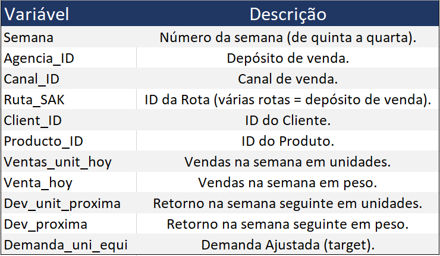

### **Carregando os Dados:**

Primeiro iremos carregar todos os pacotes que serão utilizados durante o projeto. Em seguida iremos aumentar o limite de memoria utilizada pelo R para não termos problemas.

Agora, usando o pacote *data.table*, carregamos os datasets de treino e teste. Esse pacote permite carregar com maior eficiência grandes conjuntos de dados, como o que trabalhamos aqui.

```r
train <- fread("train.csv")
```

```r
test <- fread("test.csv")
```

### **Exploração dos Dados:**

Os dados isolados nos dizem quase nada, por isso é preciso extrair informações dos dados através do entendimento das suas distribuições, relações, etc. É exatamente isso que faremos na Análise Exploratória.

Primeiro iremos compreender quão grande são as variáveis categóricas, para podermos decidir como utiliza-las. Posteriormente geraremos gráficos para um melhor entendimento de suas distribuições e visualização de valores extremos.

```r
head(train, 2)
```

```
##    Semana Agencia_ID Canal_ID Ruta_SAK Cliente_ID Producto_ID Venta_uni_hoy
## 1:      3       1110        7     3301      15766        1212             3
## 2:      3       1110        7     3301      15766        1216             4
##    Venta_hoy Dev_uni_proxima Dev_proxima Demanda_uni_equil
## 1:     25.14               0           0                 3
## 2:     33.52               0           0                 4
```

```r
unique(train$Semana)
```

```
## [1] 3 4 5 6 7 8 9
```

```r
length(unique(train$Agencia_ID))
```

```
## [1] 552
```

```r
unique(train$Canal_ID)
```

```
## [1]  7  8 11  1  4  2  6  5  9
```

```r
length(unique(train$Ruta_SAK))
```

```
## [1] 3603
```

```r
length(unique(train$Cliente_ID))
```

```
## [1] 880604
```

```r
length(unique(train$Producto_ID))
```

```
## [1] 1799
```

Como visto acima, o dataset de treino tem 7 semanas de documentação. Possuindo 552 registros únicos na variável Agencia_ID, ou seja, 552 depósitos de vendas diferentes. 9 possíveis canais de vendas. 3.603 rotas de entregas disponíveis. Uma enorme quantidades de clientes. E, por fim, verifica-se mais de 1000 produtos ofertados.

É importante ressaltar que, em relação aos clientes, verificamos 880.604 IDs diferentes. Isso não significa possuir 880.604 clientes únicos, pois, como documentado pela própria empresa, há clientes com IDs duplicados.

##### **Gráficos:**

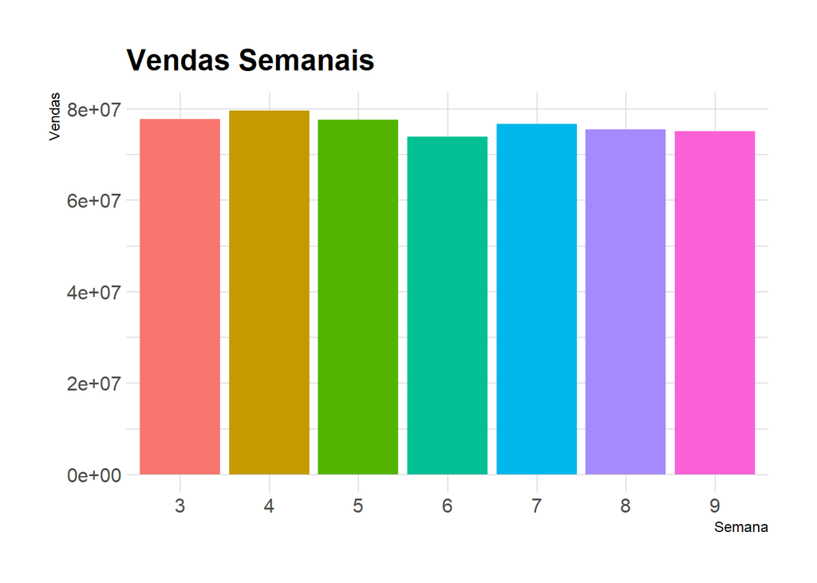

```r
train %>%
  group_by(Semana) %>%
  summarise(total = sum(Demanda_uni_equil)) %>%
  arrange(-total) %>%
  ggplot(aes(x = factor(Semana), y = total, fill = factor(Semana))) +
  geom_bar(stat = "identity",
           show.legend = FALSE) +
  labs(title = "Vendas Semanais",
       x = "Semana",
       y = "Vendas") +
  theme_tinyhand(base_size = 12)
```

As semanas não possuem diferenças relevantes de vendas.

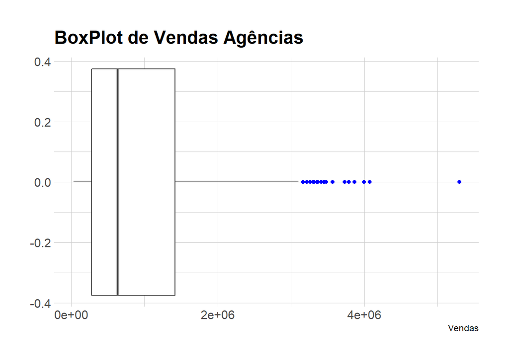

```r
train %>%
  group_by(Agencia_ID) %>%
  summarise(soma = sum(Demanda_uni_equil)) %>%
  arrange(-soma) %>%
  ggplot(aes(x = soma)) +
  geom_boxplot(outlier.colour = "blue") +
  labs(title = "BoxPlot de Vendas Agências",
       x = "Vendas") +
  theme_tinyhand(base_size = 12)
```

Há Agências com vendas discrepantes.

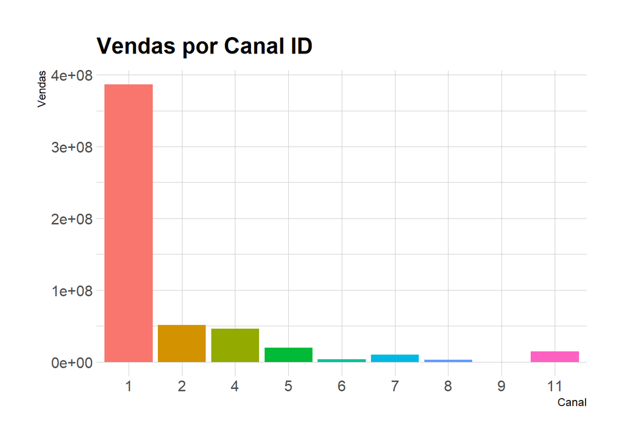

```r
train %>%
  group_by(Canal_ID) %>%
  summarise(soma = sum(Demanda_uni_equil)) %>%
  arrange(-soma) %>%
  ggplot(aes(x = factor(Canal_ID), y = soma, fill = factor(Canal_ID))) +
  geom_bar(stat = "identity",
           show.legend = FALSE) +
  labs(title = "Vendas por Canal ID",
       x = "Canal",
       y = "Vendas") +
  theme_tinyhand(base_size = 12)
```

Os Canais possuem diferenças no volume de vendas, portanto, o canal afeta a Demanda.

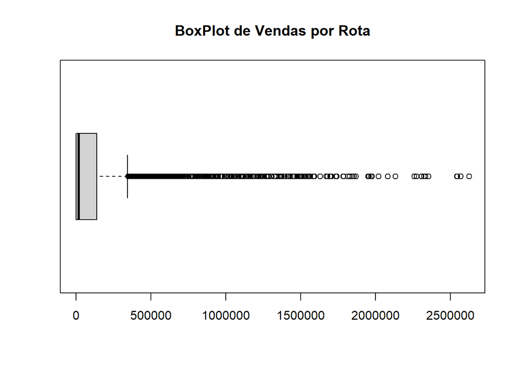

```r
boxplot((train %>%
           group_by(Ruta_SAK) %>%
           summarise(soma = sum(Demanda_uni_equil)))[,2],
        horizontal = TRUE)
title("BoxPlot de Vendas por Rota")
```

A variável Rota_ID possui muitos valores discrepantes.

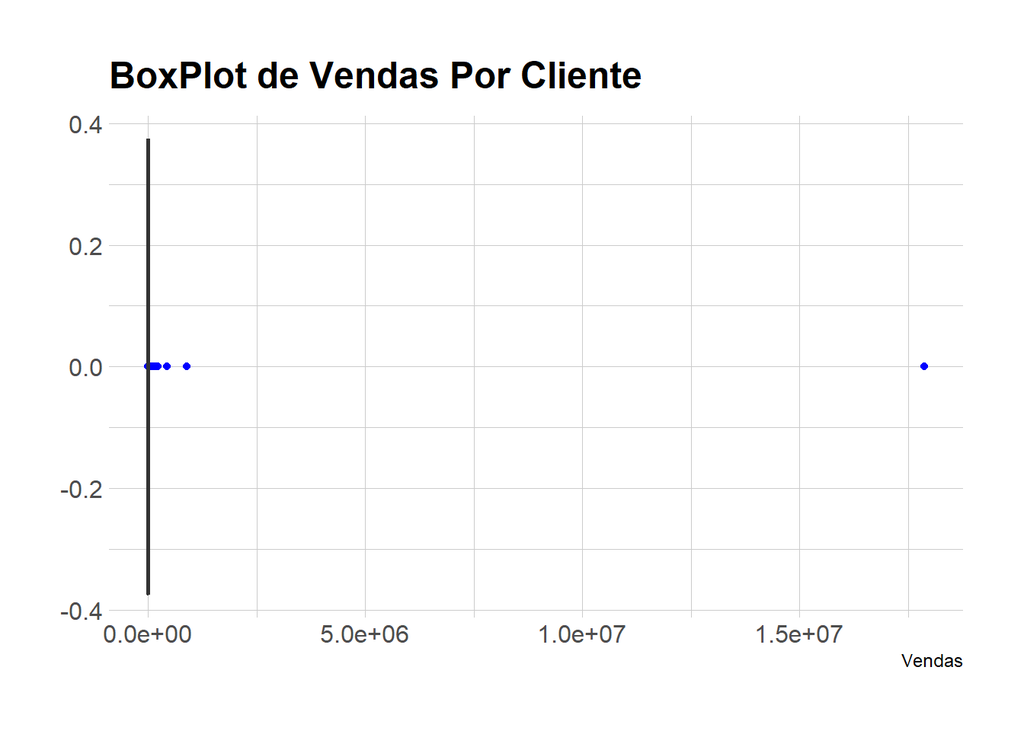

```r
train %>%
  group_by(Cliente_ID) %>%
  summarise(soma = sum(Demanda_uni_equil)) %>%
  ggplot(aes(x = soma)) +
  geom_boxplot(outlier.colour = "blue") +
  labs(title = "BoxPlot de Vendas Por Cliente",
       x = "Vendas") +
  theme_tinyhand(base_size = 12)
```

Podemos ver a existência de um cliente que compra muito, ficando muito distante do padrão. Posteriormente trataremos esse cliente.

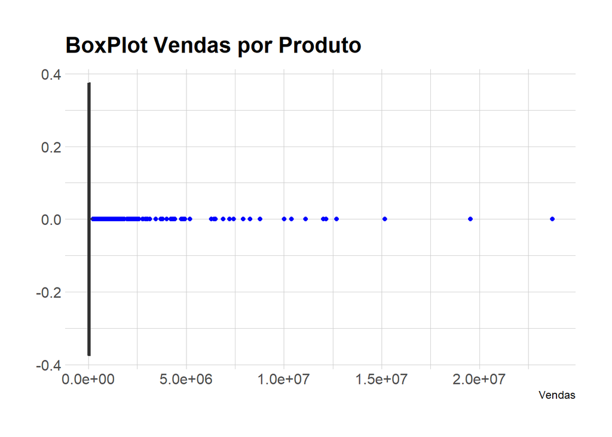

```r
train %>%
  group_by(Producto_ID) %>%
  summarise(soma = sum(Demanda_uni_equil)) %>%
  ggplot(aes(x = soma)) +
  geom_boxplot(outlier.color = "blue") +
  labs(title = "BoxPlot Vendas por Produto",
       x = "Vendas") +
  theme_tinyhand(base_size = 12)
```

Há produtos que vendem muito comparado a outros. Talvez aqui podemos encontrar o princípio de Pareto, onde 80% dos resultados (vendas) vêm de 20% dos produtos. Seria interessante uma análise sobre isso posteriormente.

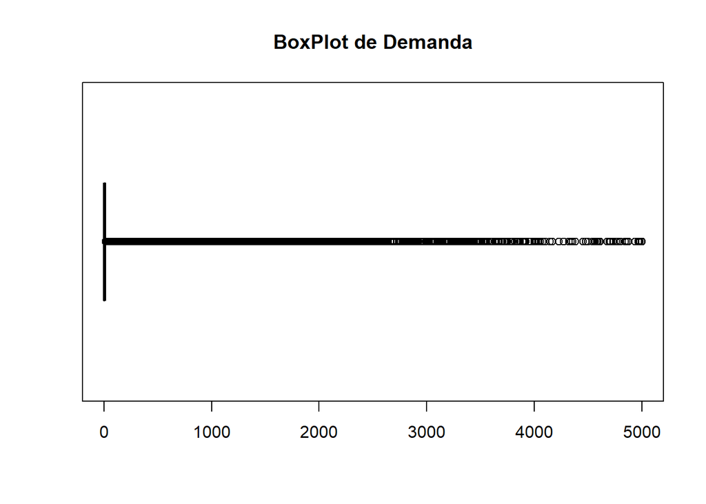

```r
boxplot(train$Demanda_uni_equil,
        horizontal = TRUE)
title("BoxPlot de Demanda")
```

Há muita demanda concentrada perto de 0. Vamos tratar isso para treinar o modelo.

### **Tratando os Dados:**

Nessa etapa iremos extrair os outliers de algumas variáveis e retirar colunas que não serão utilizadas para a construção do modelo.

```r
# Função para extrair os Outliers com maiores demandas
outlier_categorical <- function(data, col){
  require(dplyr)

  filting <- data %>%
    group_by_at(col) %>%
    summarise(soma = sum(Demanda_uni_equil)) %>%
    arrange(-soma)

  val.outliers <- boxplot.stats(filting$soma)$out
  outliers <- unlist((filting %>%
                        filter(soma %in% val.outliers))[,1])
  names(outliers) <- NULL

  return(
    data %>%
    mutate_at(c(val=col), as.integer) %>%
    filter(!val %in% outliers) %>%
    select(-val)
  )
}
```

Agora iremos utilizar a função criada anteriormente para retirar os maiores compradores. Esses foram vistos no BoxPlot de Client_ID por Demanda.

```r
train <- outlier_categorical(data = train, col = "Cliente_ID")
```

Também iremos retirar os outliers da variável *target*, Demanda_uni_equil.

```r
val.outliers <- boxplot.stats(train$Demanda_uni_equil, coef = 4.5)$out

train <- train %>%
  filter(!Demanda_uni_equil %in% val.outliers)

# Retirando da memória para liberar espaço
rm(val.outliers)
rm(outlier_categorical)
```

```r
## Retirando dados que não serão utilizados
train$Venta_uni_hoy <- NULL
train$Venta_hoy <- NULL
train$Dev_uni_proxima <- NULL
train$Dev_proxima <- NULL
```

### **Feature Engineering:**

Nessa etapa iremos transformar a variável Canal_ID e construir algumas variáveis novas a partir das variáveis originais. Isso ajuda na construção de variáveis mais eficientes para o treinamento do modelo.

Primeiro aplicaremos Dummy Coding para transformar o Canal_ID. Esse é um processo de codificação de variável categória que transforma os 9 canais possíveis em 8 variáveis que só podem conter os valores 1 ou 0.

```r
## Transformando Variável Canal_ID - Aplicando Dummy Coding
train <- dummy_cols(.data = train, select_columns = "Canal_ID", remove_first_dummy =
                      TRUE)
train$Canal_ID <- NULL
glimpse(train)
```

```
## Rows: 50,217,164
## Columns: 14
## $ Semana            <int> 3, 3, 3, 3, 3, 3, 3, 3, 3, 3, 3, 3, 3, 3, 3, 3, 3...
## $ Agencia_ID        <int> 1110, 1110, 1110, 1110, 1110, 1110, 1110, 1110, 1...
## $ Ruta_SAK          <int> 3301, 3301, 3301, 3301, 3301, 3301, 3301, 3301, 3...
## $ Cliente_ID        <int> 15766, 15766, 15766, 15766, 15766, 15766, 15766, ...
## $ Producto_ID       <int> 1212, 1216, 1238, 1240, 1242, 1250, 1309, 3894, 4...
## $ Demanda_uni_equil <int> 3, 4, 4, 4, 3, 5, 3, 6, 4, 6, 8, 4, 12, 7, 10, 5,...
## $ Canal_ID_2        <int> 0, 0, 0, 0, 0, 0, 0, 0, 0, 0, 0, 0, 0, 0, 0, 0, 0...
## $ Canal_ID_4        <int> 0, 0, 0, 0, 0, 0, 0, 0, 0, 0, 0, 0, 0, 0, 0, 0, 0...
## $ Canal_ID_5        <int> 0, 0, 0, 0, 0, 0, 0, 0, 0, 0, 0, 0, 0, 0, 0, 0, 0...
## $ Canal_ID_6        <int> 0, 0, 0, 0, 0, 0, 0, 0, 0, 0, 0, 0, 0, 0, 0, 0, 0...
## $ Canal_ID_7        <int> 1, 1, 1, 1, 1, 1, 1, 1, 1, 1, 1, 1, 1, 1, 1, 1, 1...
## $ Canal_ID_8        <int> 0, 0, 0, 0, 0, 0, 0, 0, 0, 0, 0, 0, 0, 0, 0, 0, 0...
## $ Canal_ID_9        <int> 0, 0, 0, 0, 0, 0, 0, 0, 0, 0, 0, 0, 0, 0, 0, 0, 0...
## $ Canal_ID_11       <int> 0, 0, 0, 0, 0, 0, 0, 0, 0, 0, 0, 0, 0, 0, 0, 0, 0...
```

Em seguida criaremos novas variáveis a partir da média da demanda e da probabilidade das Agências e dos Produtos. Além disso, iremos excluir as variáveis Semana, Ruta_SAK e Cliente_ID que escolhi não usar para a construção do modelo.

```r
train$Semana <- NULL
train$Ruta_SAK <- NULL
train$Cliente_ID <- NULL

train <- train %>%
  group_by(Producto_ID) %>%
  mutate(mean_prod = sum(Demanda_uni_equil)/n(),
         prop_prod = n()/nrow(train))

head(train[, c(12,13)])
```

```
## # A tibble: 6 x 2
##   mean_prod prop_prod
##       <dbl>     <dbl>
## 1      2.02    0.0180
## 2      2.10    0.0148
## 3      2.22    0.0176
## 4      3.85    0.0348
## 5      3.74    0.0330
## 6      3.89    0.0294
```

```r
train <- train %>%
  group_by(Agencia_ID) %>%
  mutate(mean_agen = sum(Demanda_uni_equil)/ n(),
         prop_agen = n()/nrow(train))

head(train[, c(14,15)])
```

```
## # A tibble: 6 x 2
##   mean_agen prop_agen
##       <dbl>     <dbl>
## 1      5.09  0.000720
## 2      5.09  0.000720
## 3      5.09  0.000720
## 4      5.09  0.000720
## 5      5.09  0.000720
## 6      5.09  0.000720
```

Por fim, vamos normalizar as variáveis contínuas e separar as agências e os produtos para juntar com os dados de teste posteriormente.

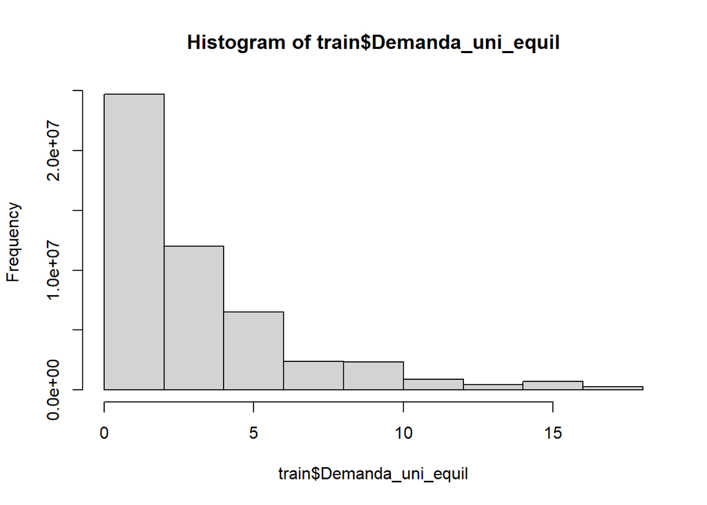

```r
## Normalizando variável target, possui muito valores 0
hist(train$Demanda_uni_equil, breaks = 10)
```

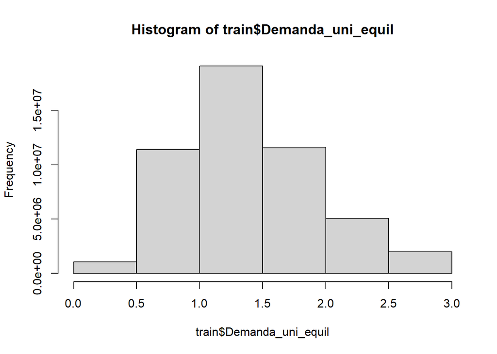

```r
train$Demanda_uni_equil <- log1p(train$Demanda_uni_equil)
hist(train$Demanda_uni_equil, breaks = 10)
```

```r
## Normalizando outra variáveis
train$mean_prod <- scale(train$mean_prod)[,1]
train$mean_agen <- scale(train$mean_agen)[,1]
train$prop_prod <- scale(train$prop_prod)[,1]
train$prop_agen <- scale(train$prop_agen)[,1]
```

```r
## Separando Dataset dos Produtos, por Produto único
producto <- train[, c(2, 13, 12)] %>%
  distinct()

train$Producto_ID <- NULL

## Separando Dataset das Agencias, por Agência única
agencia <- train %>%
  select(Agencia_ID, mean_agen, prop_agen) %>%
  distinct()

train$Agencia_ID <- NULL
```

### **Dividindo Dataset de Treino:**

Para podermos ter uma ideia da precisão do modelo será preciso dividir o dataset de treino em dois. Tem-se como resultado um dataset de fato para treinamento do modelo, 70% do conjunto anterior, e outro dataset de teste, 30% do conjunto anterior.

```r
glimpse(train)
```

```
## Rows: 50,217,164
## Columns: 13
## $ Demanda_uni_equil <dbl> 1.386294, 1.609438, 1.609438, 1.609438, 1.386294,...
## $ Canal_ID_2        <int> 0, 0, 0, 0, 0, 0, 0, 0, 0, 0, 0, 0, 0, 0, 0, 0, 0...
## $ Canal_ID_4        <int> 0, 0, 0, 0, 0, 0, 0, 0, 0, 0, 0, 0, 0, 0, 0, 0, 0...
## $ Canal_ID_5        <int> 0, 0, 0, 0, 0, 0, 0, 0, 0, 0, 0, 0, 0, 0, 0, 0, 0...
## $ Canal_ID_6        <int> 0, 0, 0, 0, 0, 0, 0, 0, 0, 0, 0, 0, 0, 0, 0, 0, 0...
## $ Canal_ID_7        <int> 1, 1, 1, 1, 1, 1, 1, 1, 1, 1, 1, 1, 1, 1, 1, 1, 1...
## $ Canal_ID_8        <int> 0, 0, 0, 0, 0, 0, 0, 0, 0, 0, 0, 0, 0, 0, 0, 0, 0...
## $ Canal_ID_9        <int> 0, 0, 0, 0, 0, 0, 0, 0, 0, 0, 0, 0, 0, 0, 0, 0, 0...
## $ Canal_ID_11       <int> 0, 0, 0, 0, 0, 0, 0, 0, 0, 0, 0, 0, 0, 0, 0, 0, 0...
## $ mean_prod         <dbl> -0.90997117, -0.86706445, -0.80102832, 0.09209436...
## $ prop_prod         <dbl> 0.4904024, 0.1873190, 0.4523020, 2.0764984, 1.910...
## $ mean_agen         <dbl> 3.806717, 3.806717, 3.806717, 3.806717, 3.806717,...
## $ prop_agen         <dbl> -1.832916, -1.832916, -1.832916, -1.832916, -1.83...
```

```r
setDT(train)
```

```r
index <- sample(1:nrow(train), size = 0.7 * nrow(train), replace = FALSE)

logical <- vector()
length(logical) <- nrow(train)

for (i in index) {
  logical[i] <- 1
}

logical <- ifelse(is.na(logical) == TRUE, 0, 1)
train$index <- logical

# Removendo da Memória o que não será mais usado
rm(logical)
rm(index)
rm(i)

# Dividindo pelo Dplyr, pois é mais rápido que train[index,]
teste <- train %>%
  filter(index == 0) %>%
  select(-index)

train <- train %>%
  filter(index == 1) %>%
  select(-index)
```

```r
# Salvando dataset de teste para facilitar utilizações posterior
# e liberar espaço na memória
write_csv(teste, "teste2.csv")
rm(teste)
```

### **Dataset de Teste Oficial:**

Vamos preparar o dataset de teste oficial. Aplicaremos Dummy Coding, removeremos algumas variáveis e faremos um join com os dados de média e probabilidade por Produto e Agência. Então, salvaremos os dados de teste obtido para liberar espaço em memória.

```r
glimpse(test)
```

```
## Rows: 6,999,251
## Columns: 7
## $ id          <int> 0, 1, 2, 3, 4, 5, 6, 7, 8, 9, 10, 11, 12, 13, 14, 15, 1...
## $ Semana      <int> 11, 11, 10, 11, 11, 11, 11, 10, 10, 11, 11, 10, 11, 10,...
## $ Agencia_ID  <int> 4037, 2237, 2045, 1227, 1219, 1146, 2057, 1612, 1349, 1...
## $ Canal_ID    <int> 1, 1, 1, 1, 1, 4, 1, 1, 1, 1, 1, 1, 1, 1, 1, 1, 1, 1, 1...
## $ Ruta_SAK    <int> 2209, 1226, 2831, 4448, 1130, 6601, 4507, 2837, 1223, 1...
## $ Cliente_ID  <int> 4639078, 4705135, 4549769, 4717855, 966351, 1741414, 46...
## $ Producto_ID <int> 35305, 1238, 32940, 43066, 1277, 972, 1232, 35305, 1240...
```

```r
# Removendo algumas variáveis
test$Semana <- NULL
test$Ruta_SAK <- NULL
test$Cliente_ID <- NULL

# Fazendo Dummy Coding
test <- dummy_cols(.data = test, select_columns = "Canal_ID", remove_first_dummy = TRUE)

# Left Join
test <- test %>%
  left_join(producto, by = "Producto_ID")

test <- test %>%
  left_join(agencia, by = "Agencia_ID")

# Removendo mais algumas variáveis
test$Agencia_ID <- NULL
test$Canal_ID <- NULL
test$Producto_ID <- NULL

glimpse(test)
```

```
## Rows: 6,999,251
## Columns: 13
## $ id          <int> 0, 1, 2, 3, 4, 5, 6, 7, 8, 9, 10, 11, 12, 13, 14, 15, 1...
## $ Canal_ID_2  <int> 0, 0, 0, 0, 0, 0, 0, 0, 0, 0, 0, 0, 0, 0, 0, 0, 0, 0, 0...
## $ Canal_ID_4  <int> 0, 0, 0, 0, 0, 1, 0, 0, 0, 0, 0, 0, 0, 0, 0, 0, 0, 0, 0...
## $ Canal_ID_5  <int> 0, 0, 0, 0, 0, 0, 0, 0, 0, 0, 0, 0, 0, 0, 0, 0, 0, 0, 0...
## $ Canal_ID_6  <int> 0, 0, 0, 0, 0, 0, 0, 0, 0, 0, 0, 0, 0, 0, 0, 0, 0, 0, 0...
## $ Canal_ID_7  <int> 0, 0, 0, 0, 0, 0, 0, 0, 0, 0, 0, 0, 0, 0, 0, 0, 0, 0, 0...
## $ Canal_ID_8  <int> 0, 0, 0, 0, 0, 0, 0, 0, 0, 0, 0, 0, 0, 0, 0, 0, 0, 0, 0...
## $ Canal_ID_9  <int> 0, 0, 0, 0, 0, 0, 0, 0, 0, 0, 0, 0, 0, 0, 0, 0, 0, 0, 0...
## $ Canal_ID_11 <int> 0, 0, 0, 0, 0, 0, 0, 0, 0, 0, 0, 0, 0, 0, 0, 0, 0, 0, 0...
## $ prop_prod   <dbl> -0.43599335, 0.45230199, -0.92010014, -0.90332404, -1.2...
## $ mean_prod   <dbl> 1.52082365, -0.80102832, -0.28943685, -1.08815693, -0.1...
## $ mean_agen   <dbl> -1.22435067, -0.86744161, 0.25255482, -0.97935295, -0.4...
## $ prop_agen   <dbl> 0.994263784, 1.367303828, -0.439683381, 1.457925755, 1....
```

```r
sum(is.na(test))
```

```
## [1] 171538
```

```r
# Liberando espaço na memória
write.csv(test, "test2.csv")
```

```r
rm(agencia)
rm(producto)
rm(test)
```

### **Treinando o Modelo:**

Escolhemos o algoritmo XGBoost por ser um algoritmo muito mais flexível e ser computacionalmente mais rápido quando aplicado em conjuntos de treino com grande quantidade de dados. Além disso, o XGBoost lida muito bem com valores faltantes, como os que temos no dataset anterior.

```r
# Criando DMatrix
labels <- train$Demanda_uni_equil
train <- train[, -1]

dtrain <- xgb.DMatrix(data = as.matrix(train),
                      label = labels, missing = NA)

rm(labels)
rm(train)

#write_rds(dtrain, "dtrain.rds")
```

```r
# Treinando o Modelo
model <- xgb.train(
  params = list(
    objective = "reg:squarederror",
    booster = "gbtree",
    eta = 0.2,
    max_depth = 5,
    subsample = 0.7,
    colsample_bytree = 0.7
  ), data = dtrain,
  nrounds = 100,
  verbose = T,
  print_every_n = 5,
  maximize = FALSE,
  nthread = 16
)

#write_rds(model, "model.rds")
```

### **Avaliando o Modelo:**

Avaliando o modelo nos dados de teste que derivamos do dataset de treino.

```r
# Carregando os dados que salvamos anteriormente
test1 <- read_csv("teste2.csv")

head(test1)
```

```
## # A tibble: 6 x 13
##   Demanda_uni_equ~ Canal_ID_2 Canal_ID_4 Canal_ID_5 Canal_ID_6 Canal_ID_7
##              <dbl>      <dbl>      <dbl>      <dbl>      <dbl>      <dbl>
## 1             1.39          0          0          0          0          1
## 2             1.95          0          0          0          0          1
## 3             2.20          0          0          0          0          1
## 4             2.56          0          0          0          0          1
## 5             2.08          0          0          0          0          1
## 6             2.20          0          0          0          0          1
## # ... with 7 more variables: Canal_ID_8 <dbl>, Canal_ID_9 <dbl>,
## #   Canal_ID_11 <dbl>, mean_prod <dbl>, prop_prod <dbl>, mean_agen <dbl>,
## #   prop_agen <dbl>
```

```r
# Separando a variável target das outras
Y <- test1$Demanda_uni_equil
test1 <- test1 %>% select(-Demanda_uni_equil)

# Fazendo as previsões e voltando o padrão dos resultados
previsoes <- predict(model, as.matrix(test1))
previsoes <- expm1(previsoes)
```

```r
# Tratando as previsões negativas, se existirem
# Pois não existe demanda menor do que 0

for (i in 1:length(previsoes)) {
  if (previsoes[i] < 0) {
    previsoes[i] = 0
  }
}
```

```r
# Calculando o R-Squared
actual <- expm1(Y)

rss <- sum((previsoes - actual) ^ 2)
tss <- sum((actual - mean(actual)) ^ 2)
rsq <- 1 - (rss/tss)
rsq
```

```
## [1] 0.3071772
```

### **Prevendo no Dataset de Teste Oficial:**

```r
# Carregando o dataset de teste oficial salvo
test <- read_csv("test2.csv", col_types = cols("i","i", "i", "i", "i", "i", "i", "i", "i", "i",
                                                "d", "d","d", "d"))

# Reposicionando as colunas e retirando a variável X1 que o write_csv criou
test <- test %>%
  relocate(X1,id,Canal_ID_2,Canal_ID_4,Canal_ID_5,Canal_ID_6,Canal_ID_7,Canal_ID_8,
           Canal_ID_9, Canal_ID_11, mean_prod, prop_prod, mean_agen, prop_agen) %>%
  select(-X1)

# Prevendo
previsoes.of <- predict(model, as.matrix(test %>% select(-id)))
previsoes.of <- expm1(previsoes.of)

# Verificando se existe previsões negativas
sum(previsoes.of < 0)
```

```
## [1] 0
```

```r
# Como não existe demanda quebrada
previsoes.of <- round(previsoes.of)

## Criando Data Frame para submissão e salvando
df.submission <- data.frame(id = test$id,
                            Demanda_uni_equil = previsoes.of)

head(df.submission)
tail(df.submission)

write_csv(df.submission, "submission.csv")
```

Após submissão do dataset no Kaggle obtemos Score:

**Privado**: 0.75518

**Público**: 0.74425

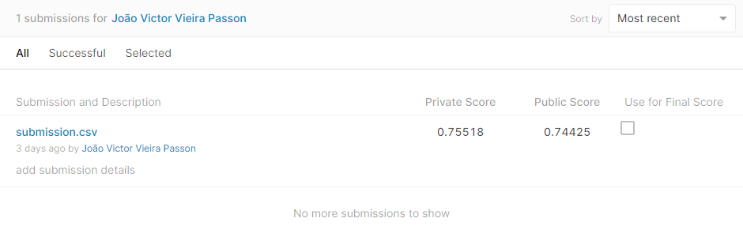

### **Contato:**

Qualquer dúvida, sugestão ou outros motivos fico a inteira disposição para conversar!

E-mail: victor.passon@yahoo.com.br

Linkedin: https://www.linkedin.com/in/victorpasson/

Github: https://github.com/victorpasson

Site Portfolio: http://victorpasson.github.io/

[Voltar](http://victorpasson.github.io/)